# week9_assignment_PVK

Part 1: Rmarkdown Create a new Rmarkdown document and save it as week9_assignment_ABC.Rmd with your initals in place of ABC.

##### Tell your coding partner about your research! Write a small paragraph about what you think (or know) your central research question might be for your PhD or Masters. Bold your main question, italicize the name of your study species, and be sure to include a picture of your study species/study site/or another picture.

The goal of my research is to better understand **how climate influences temperate forests, and vice versa**. My current projects will use dendrochronology and stable isotope analysis, along with remote sensing and eddy covariance data, to examine the effects of drought and CO2 on *Western mixed conifer species*.

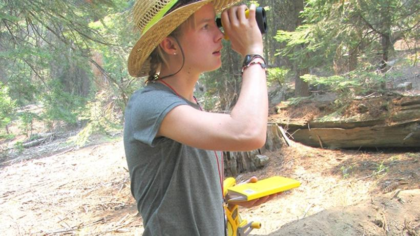

Knit your Rmrkdown document. Hide the messages from appearing in the knited document. Save and push to Github.

Pull down your partner’s Rmarkdown and see if you can knit the document on your computer.